# BST 210 PROJECT

```r
#install.packages("splitstackshape")
#install.packages("gtools")
#install.packages("ResourceSelection")
#install.packages("LogisticDx")
#install.packages("ROCR")
#install.packages("ggplot2")
#install.packages("knitr")
#install.packages("ISLR")

library(tidyverse)
library(dplyr)
library(splines)
library(splines2)
library(ISLR)
library(gtools)
library(splitstackshape)
library(ResourceSelection)
library(LogisticDx)
library(ROCR)
library(ggplot2)

hiv <- read.csv(file ="data/hivstat.csv", header = TRUE, sep = ",")

baseline <- read.csv(file ="data/f00.csv", header = TRUE, sep = ",")

sociodemographic <-read.csv(file ="data/f01.csv", header = TRUE, sep =",")

medhistory <- read.csv(file = "data/hx_cleaned.csv", header = TRUE, sep = ",")

outcome <- read.csv(file = "data/outcome_cleaned.csv", header = TRUE, sep = ",")

alc_drugs <- read.csv(file = "data/f04.csv", header = TRUE, sep = ",")

join1 <- inner_join(hiv, baseline, by = "CASEID" )
join2 <- inner_join(join1, sociodemographic, by ="CASEID")
join3 <- inner_join(join2, medhistory, by = "CASEID")
join4 <- inner_join(join3, outcome, by = "CASEID")
join5 <- inner_join(join4, alc_drugs, by = "CASEID")
all <- join5

all <- all[, c("CASEID", "STATUS", "SPANSC", "AGE_SC", "RACESC", "EDUCSC", "MOMESC", "IDU_SC", "PARTSC", "FPOSSC", "COB_SD", "MAR_SD","NRESSD", "INC_SD","FMCNHX", "FMHBHX", "FMCLHX", "FMDBHX", "KDHXHX", "MAGEHX", "EVMIHX", "EVCFHX", "EVSTHX", "EVHCHX","EVLCHX", "EVLVHX", "EHRTHX", "OUTCAIDS", "OUTCCANC", "OUTCTB", "OUTCDTH", "EPOTBH", "EDTXBH", "SHARBH", "EVIDBH", "EVODBH", "EVHDBH", "EVJLBH", "MHIVBH", "MMANBH", "MVCDBH", "MEANBH", "FTOYBH", "ORNTBH")]

colnames(all) <- c("CASEID", "hivstat", "speak_spanish", "age", "ethnicity", "educ_level", "mother_educ", "drug", "sex_partners","first_pos_test", "birth_country", "marital_status", "living_with", "household_income", "family_cancer", "family_hbp", "family_cholesterol", "family_diabetes", "family_kidney" ," first_menstruation", "ever_mi", "ever_chf", "ever_stroke", "ever_highcholesterol", "ever_lung_clot", "ever_liverprob", "ever_hrt", "aids", "cancer", "tb", "death", "ever_marijuana", "ever_drug_treatment", "shared_needles", "ever_in_drug_detox", "ever_out_drug_detox", "ever_halfway_house", "ever_jail", "ever_sex_with_hiv_male", "ever_sex_with_gay_male", "condom_use", "ever_anal_sex", "ever_sex_toys", "sexual_orientation")

all$hivstat[all$hivstat == 4] <- 2
all$hivstat[all$hivstat == 1] <- 0
all$hivstat[all$hivstat == 2] <- 1

CASEID <- all$CASEID
hivstat <- all$hivstat
speak_spanish <- all$speak_spanish
age <- all$age
ethnicity <- all$ethnicity
educ_level <- all$educ_level
mother_educ <- all$mother_educ
drug <- all$drug
sex_partners <- all$sex_partners
birth_country <- all$birth_country
marital_status <- all$marital_status
household_income <- all$household_income
family_cancer <- all$family_cancer
family_hbp <- all$family_hbp
family_cholesterol <- all$family_cholesterol
family_diabetes <- all$family_diabetes
first_menstruation <- all$first_menstruation
ever_hrt <- all$ever_hrt
aids <- all$aids
cancer <- all$cancer
tb <- all$tb
death <- all$death
first_pos_test <- all$first_pos_test
living_with <- all$living_with
family_kidney <- all$family_kidney
ever_mi <- all$ever_mi
ever_chf <-all$ever_chf
ever_stroke <- all$ever_stroke
ever_highcholesterol <- all$ever_highcholesterol
ever_lung_clot <- all$ever_lung_clot
ever_liverprob <- all$ever_liverprob
ever_marijuana <- all$ever_marijuana
ever_drug_treatment <- all$ever_drug_treatment
shared_needles <- all$shared_needles
ever_in_drug_detox <- all$ever_in_drug_detox
ever_out_drug_detox <- all$ever_out_drug_detox
ever_halfway_house <- all$ever_halfway_house
ever_jail <- all$ever_jail
ever_sex_with_hiv_male <- all$ever_sex_with_hiv_male
ever_sex_with_gay_male <- all$ever_sex_with_gay_male
condom_use <- all$condom_use
ever_anal_sex <- all$ever_anal_sex
ever_sex_toys <- all$ever_sex_toys
sexual_orientation <-all$sexual_orientation
```

HIV STATUS: 0: Negative 1: Prevalent

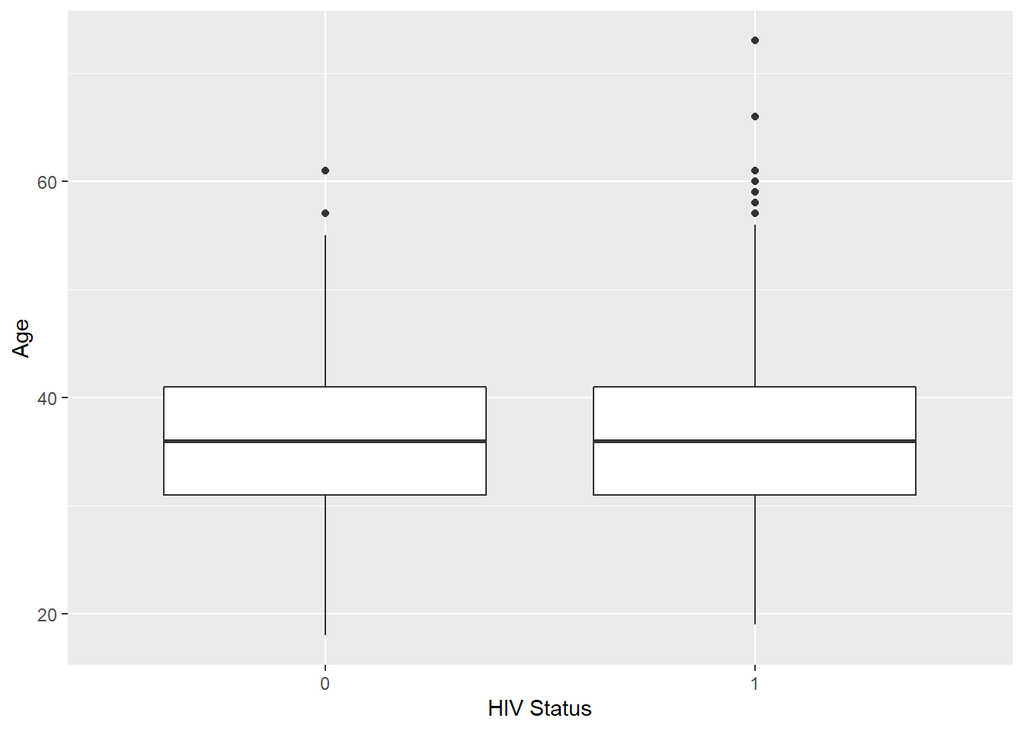

```r
all %>% ggplot()+
  geom_boxplot(aes(factor(hivstat), age))+
  labs(x = "HIV Status", y = "Age")
```

We notice that there is no significant different in the ages of those with HIV infection compared to those without HIV

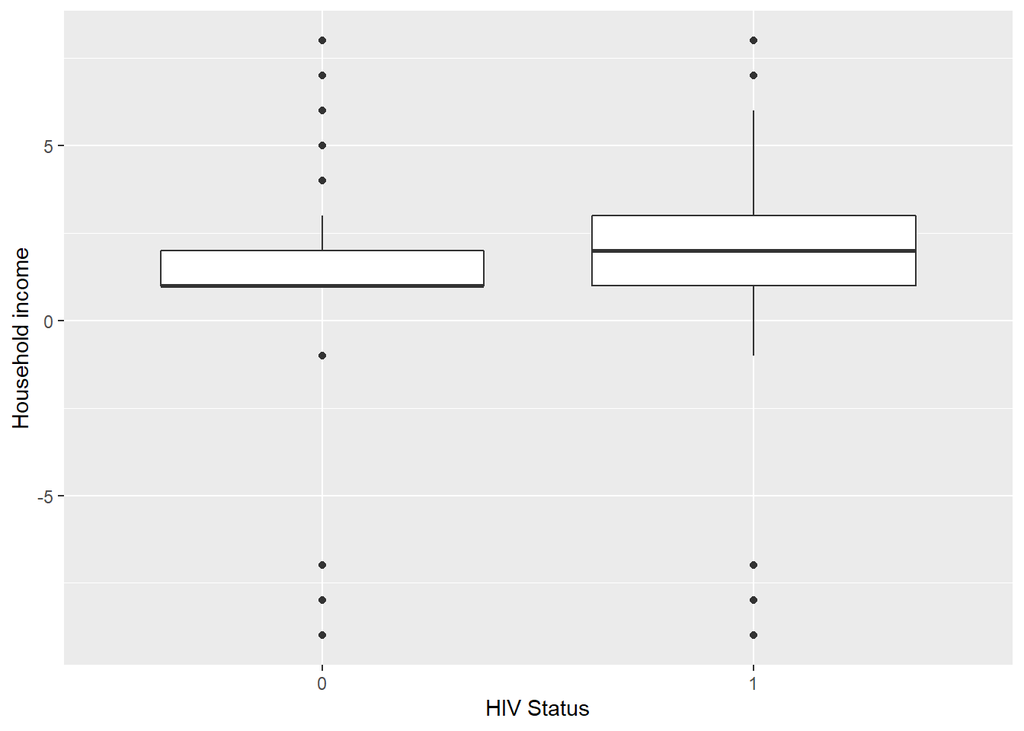

```r
all %>%
  ggplot(aes(x = factor(hivstat), y = household_income)) +
  geom_boxplot()+
  labs(x = "HIV Status", y = "Household income")
```

There seems to be a little bit of a higher household income among those with HIV than those without HIV

```r
aids_proportion <- with(all, table(aids, hivstat)) %>% prop.table(margin = 2)
aids_proportion
```

```
##     hivstat
## aids        0        1
##    0 1.000000 0.705314
##    1 0.000000 0.294686
```

Among those with HIV (hivstat = 1), only 29% have developed AIDS. This shows that HIV does not always lead to AIDS (contrarily to popular belief)

```r
partners_prop <- with(all, table(sex_partners, hivstat)) %>% prop.table(margin = 1)
partners_prop
```

```
##             hivstat
## sex_partners         0         1
##           -8 0.0000000 1.0000000
##           1  0.0000000 1.0000000
##           2  0.1761364 0.8238636
##           3  0.1409396 0.8590604
##           4  0.1660900 0.8339100
##           5  0.1067961 0.8932039
```

The sex partner categories are as follows : 1: 0 or no sex partners 2: 1 to 4 partners 3: 5 to 10 partners 4: 11 to 100 partners 5: more than 100 partners -8 : don’t know

We notice that among those with more than 1 sex partner, there is always significantly more women in the study with HIV than without HIV.

```r
maritalstatus_prop <- with(all, table(marital_status, hivstat)) %>% prop.table(margin = 2)
maritalstatus_prop
```

```
##               hivstat
## marital_status           0           1
##              1 0.273195876 0.208695652
##              2 0.154639175 0.151690821
##              3 0.046391753 0.096618357
##              4 0.067010309 0.114009662
##              5 0.103092784 0.112077295
##              6 0.335051546 0.308212560
##              7 0.020618557 0.008695652
```

The marital status categories are as follows: 1: legally/common-law married 2: not married but living with partner 3: widowed 4: divorced/annulled 5: separated 6: never married 7: other

We notice that among those with HIV, the biggest proportion has never been married. Also, there seems to be a significant bigger percentage of people who are widowed or divorced among the women with HIV than those without (will also see this in the summary of the logistic model below)

```r
glm_income <- glm(hivstat ~ I(household_income), data = all, family = binomial)
summary(glm_income)
```

```
##
## Call:
## glm(formula = hivstat ~ I(household_income), family = binomial,
##     data = all)
##
## Deviance Residuals:
##     Min       1Q   Median       3Q      Max
## -2.1844   0.5042   0.5772   0.6035   0.9197
##
## Coefficients:
##                     Estimate Std. Error z value Pr(>|z|)
## (Intercept)          1.51399    0.08800  17.205  < 2e-16 ***
## I(household_income)  0.09691    0.02765   3.505 0.000456 ***
## ---
## Signif. codes:  0 '***' 0.001 '**' 0.01 '*' 0.05 '.' 0.1 ' ' 1
##
## (Dispersion parameter for binomial family taken to be 1)
##
##     Null deviance: 1071.9  on 1228  degrees of freedom
## Residual deviance: 1060.0  on 1227  degrees of freedom
## AIC: 1064
##
## Number of Fisher Scoring iterations: 4
```

At an alpha = 0.05 significance level, there seems to be a significant relationship between hiv status and household income.

```r
glm_marital <- glm (hivstat ~ as.factor(marital_status) , data = all, family = binomial)
summary(glm_marital)
```

```
##
## Call:
## glm(formula = hivstat ~ as.factor(marital_status), family = binomial,
##     data = all)
##
## Deviance Residuals:
##     Min       1Q   Median       3Q      Max
## -2.2334   0.4572   0.5914   0.6090   0.8576
##
## Coefficients:
##                            Estimate Std. Error z value Pr(>|z|)
## (Intercept)                  1.4050     0.1533   9.166  < 2e-16 ***
## as.factor(marital_status)2   0.2501     0.2514   0.995  0.31989
## as.factor(marital_status)3   1.0030     0.3801   2.638  0.00833 **
## as.factor(marital_status)4   0.8007     0.3300   2.427  0.01524 *
## as.factor(marital_status)5   0.3529     0.2866   1.231  0.21818
## as.factor(marital_status)6   0.1858     0.2050   0.907  0.36466
## as.factor(marital_status)7  -0.5941     0.6202  -0.958  0.33812
## ---
## Signif. codes:  0 '***' 0.001 '**' 0.01 '*' 0.05 '.' 0.1 ' ' 1
##
## (Dispersion parameter for binomial family taken to be 1)
##
##     Null deviance: 1071.9  on 1228  degrees of freedom
## Residual deviance: 1057.4  on 1222  degrees of freedom
## AIC: 1071.4
##
## Number of Fisher Scoring iterations: 4
```

The odds of having HIV is significantly greater for women who are widowed or divorced than for women who are legally married.

```r
death_glm <- glm(death ~ ever_highcholesterol , family = binomial)
summary(death_glm)
```

```
##
## Call:
## glm(formula = death ~ ever_highcholesterol, family = binomial)
##
## Deviance Residuals:
##     Min       1Q   Median       3Q      Max
## -0.9761  -0.9761  -0.6614   1.3930   1.8040
##
## Coefficients:
##                      Estimate Std. Error z value Pr(>|z|)
## (Intercept)           -2.3229     0.3056  -7.602 2.91e-14 ***
## ever_highcholesterol   0.9145     0.1635   5.594 2.21e-08 ***
## ---
## Signif. codes:  0 '***' 0.001 '**' 0.01 '*' 0.05 '.' 0.1 ' ' 1
##
## (Dispersion parameter for binomial family taken to be 1)
##
##     Null deviance: 1569.1  on 1228  degrees of freedom
## Residual deviance: 1532.6  on 1227  degrees of freedom
## AIC: 1536.6
##
## Number of Fisher Scoring iterations: 4
```

```r
glm_drug <- glm(hivstat ~ ever_drug_treatment, family = binomial)
summary(glm_drug)
```

```
##
## Call:
## glm(formula = hivstat ~ ever_drug_treatment, family = binomial)
##
## Deviance Residuals:
##     Min       1Q   Median       3Q      Max
## -2.0340   0.5198   0.5198   0.6371   0.6371
##
## Coefficients:
##                     Estimate Std. Error z value Pr(>|z|)
## (Intercept)           1.0493     0.2364   4.439 9.02e-06 ***
## ever_drug_treatment   0.4421     0.1620   2.730  0.00634 **
## ---
## Signif. codes:  0 '***' 0.001 '**' 0.01 '*' 0.05 '.' 0.1 ' ' 1
##
## (Dispersion parameter for binomial family taken to be 1)
##
##     Null deviance: 1071.9  on 1228  degrees of freedom
## Residual deviance: 1064.3  on 1227  degrees of freedom
## AIC: 1068.3
##
## Number of Fisher Scoring iterations: 4
```

At an alpha = 0.05 significance level, there seems to be a significant relationship between hiv status and receiving drug treatment.